# Risk Factor Analysis

## Outcome Variable

**Outcome Variable:** stunted

## Predictor Variables

**Intervention Variable:** predexfd6

**Adjustment Set:**

- arm
- sex
- W_mage
- meducyrs
- feducyrs
- hhwealth_quart
- hfoodsec
- W_mhtcm
- vagbrth
- W_gagebrth
- W_birthwt
- W_birthlen
- W_nrooms
- W_nchldlt5
- month
- brthmon
- W_parity
- impfloor
- impsan
- safeh20
- delta_W_mage
- delta_meducyrs
- delta_feducyrs
- delta_hhwealth_quart
- delta_hfoodsec
- delta_W_mhtcm
- delta_vagbrth
- delta_W_gagebrth
- delta_W_birthwt
- delta_W_birthlen
- delta_W_nrooms
- delta_W_nchldlt5
- delta_month
- delta_brthmon
- delta_W_parity
- delta_impfloor
- delta_impsan
- delta_safeh20

## Stratifying Variables

The analysis was stratified on these variable(s):

- agecat
- studyid
- country

## Data Summary

| agecat | studyid | country | predexfd6 | stunted | n_cell | n |
| --- | --- | --- | --- | --- | --- | --- |
| Birth | ki0047075b-MAL-ED | BANGLADESH | 0 | 0 | 91 | 231 |
| Birth | ki0047075b-MAL-ED | BANGLADESH | 0 | 1 | 21 | 231 |
| Birth | ki0047075b-MAL-ED | BANGLADESH | 1 | 0 | 101 | 231 |
| Birth | ki0047075b-MAL-ED | BANGLADESH | 1 | 1 | 18 | 231 |
| 6 months | ki0047075b-MAL-ED | BANGLADESH | 0 | 0 | 88 | 235 |
| 6 months | ki0047075b-MAL-ED | BANGLADESH | 0 | 1 | 24 | 235 |
| 6 months | ki0047075b-MAL-ED | BANGLADESH | 1 | 0 | 104 | 235 |
| 6 months | ki0047075b-MAL-ED | BANGLADESH | 1 | 1 | 19 | 235 |
| 24 months | ki0047075b-MAL-ED | BANGLADESH | 0 | 0 | 53 | 209 |
| 24 months | ki0047075b-MAL-ED | BANGLADESH | 0 | 1 | 44 | 209 |
| 24 months | ki0047075b-MAL-ED | BANGLADESH | 1 | 0 | 59 | 209 |
| 24 months | ki0047075b-MAL-ED | BANGLADESH | 1 | 1 | 53 | 209 |
| Birth | ki0047075b-MAL-ED | BRAZIL | 0 | 0 | 134 | 175 |
| Birth | ki0047075b-MAL-ED | BRAZIL | 0 | 1 | 14 | 175 |
| Birth | ki0047075b-MAL-ED | BRAZIL | 1 | 0 | 24 | 175 |
| Birth | ki0047075b-MAL-ED | BRAZIL | 1 | 1 | 3 | 175 |
| 6 months | ki0047075b-MAL-ED | BRAZIL | 0 | 0 | 169 | 209 |
| 6 months | ki0047075b-MAL-ED | BRAZIL | 0 | 1 | 5 | 209 |
| 6 months | ki0047075b-MAL-ED | BRAZIL | 1 | 0 | 34 | 209 |
| 6 months | ki0047075b-MAL-ED | BRAZIL | 1 | 1 | 1 | 209 |
| 24 months | ki0047075b-MAL-ED | BRAZIL | 0 | 0 | 134 | 169 |
| 24 months | ki0047075b-MAL-ED | BRAZIL | 0 | 1 | 6 | 169 |
| 24 months | ki0047075b-MAL-ED | BRAZIL | 1 | 0 | 29 | 169 |
| 24 months | ki0047075b-MAL-ED | BRAZIL | 1 | 1 | 0 | 169 |
| Birth | ki0047075b-MAL-ED | INDIA | 0 | 0 | 149 | 190 |
| Birth | ki0047075b-MAL-ED | INDIA | 0 | 1 | 26 | 190 |
| Birth | ki0047075b-MAL-ED | INDIA | 1 | 0 | 10 | 190 |
| Birth | ki0047075b-MAL-ED | INDIA | 1 | 1 | 5 | 190 |
| 6 months | ki0047075b-MAL-ED | INDIA | 0 | 0 | 174 | 232 |
| 6 months | ki0047075b-MAL-ED | INDIA | 0 | 1 | 40 | 232 |

[output cut: 143 more lines]

The following strata were considered:

- agecat: 24 months, studyid: ki0047075b-MAL-ED, country: BANGLADESH
- agecat: 24 months, studyid: ki0047075b-MAL-ED, country: BRAZIL
- agecat: 24 months, studyid: ki0047075b-MAL-ED, country: INDIA
- agecat: 24 months, studyid: ki0047075b-MAL-ED, country: NEPAL
- agecat: 24 months, studyid: ki0047075b-MAL-ED, country: PERU
- agecat: 24 months, studyid: ki0047075b-MAL-ED, country: SOUTH AFRICA
- agecat: 24 months, studyid: ki0047075b-MAL-ED, country: TANZANIA, UNITED REPUBLIC OF
- agecat: 24 months, studyid: ki1000108-CMC-V-BCS-2002, country: INDIA
- agecat: 24 months, studyid: ki1000108-IRC, country: INDIA
- agecat: 24 months, studyid: ki1017093b-PROVIDE, country: BANGLADESH
- agecat: 24 months, studyid: ki1101329-Keneba, country: GAMBIA
- agecat: 24 months, studyid: ki1113344-GMS-Nepal, country: NEPAL
- agecat: 24 months, studyid: ki1148112-LCNI-5, country: MALAWI
- agecat: 24 months, studyid: kiGH5241-JiVitA-3, country: BANGLADESH
- agecat: 24 months, studyid: kiGH5241-JiVitA-4, country: BANGLADESH
- agecat: 6 months, studyid: ki0047075b-MAL-ED, country: BANGLADESH
- agecat: 6 months, studyid: ki0047075b-MAL-ED, country: BRAZIL
- agecat: 6 months, studyid: ki0047075b-MAL-ED, country: INDIA
- agecat: 6 months, studyid: ki0047075b-MAL-ED, country: NEPAL
- agecat: 6 months, studyid: ki0047075b-MAL-ED, country: PERU
- agecat: 6 months, studyid: ki0047075b-MAL-ED, country: SOUTH AFRICA
- agecat: 6 months, studyid: ki0047075b-MAL-ED, country: TANZANIA, UNITED REPUBLIC OF
- agecat: 6 months, studyid: ki1000108-CMC-V-BCS-2002, country: INDIA
- agecat: 6 months, studyid: ki1000108-IRC, country: INDIA
- agecat: 6 months, studyid: ki1000109-EE, country: PAKISTAN
- agecat: 6 months, studyid: ki1000304b-SAS-CompFeed, country: INDIA
- agecat: 6 months, studyid: ki1000304b-SAS-FoodSuppl, country: INDIA
- agecat: 6 months, studyid: ki1017093b-PROVIDE, country: BANGLADESH
- agecat: 6 months, studyid: ki1101329-Keneba, country: GAMBIA
- agecat: 6 months, studyid: ki1113344-GMS-Nepal, country: NEPAL
- agecat: 6 months, studyid: ki1148112-LCNI-5, country: MALAWI
- agecat: 6 months, studyid: kiGH5241-JiVitA-3, country: BANGLADESH
- agecat: 6 months, studyid: kiGH5241-JiVitA-4, country: BANGLADESH
- agecat: Birth, studyid: ki0047075b-MAL-ED, country: BANGLADESH
- agecat: Birth, studyid: ki0047075b-MAL-ED, country: BRAZIL
- agecat: Birth, studyid: ki0047075b-MAL-ED, country: INDIA
- agecat: Birth, studyid: ki0047075b-MAL-ED, country: NEPAL
- agecat: Birth, studyid: ki0047075b-MAL-ED, country: PERU
- agecat: Birth, studyid: ki0047075b-MAL-ED, country: SOUTH AFRICA
- agecat: Birth, studyid: ki0047075b-MAL-ED, country: TANZANIA, UNITED REPUBLIC OF
- agecat: Birth, studyid: ki1000108-CMC-V-BCS-2002, country: INDIA
- agecat: Birth, studyid: ki1000108-IRC, country: INDIA
- agecat: Birth, studyid: ki1000109-EE, country: PAKISTAN
- agecat: Birth, studyid: ki1000304b-SAS-CompFeed, country: INDIA
- agecat: Birth, studyid: ki1101329-Keneba, country: GAMBIA
- agecat: Birth, studyid: kiGH5241-JiVitA-3, country: BANGLADESH
- agecat: Birth, studyid: kiGH5241-JiVitA-4, country: BANGLADESH

### Dropped Strata

Some strata were dropped due to rare outcomes:

- agecat: Birth, studyid: ki0047075b-MAL-ED, country: BRAZIL
- agecat: 6 months, studyid: ki0047075b-MAL-ED, country: BRAZIL
- agecat: 24 months, studyid: ki0047075b-MAL-ED, country: BRAZIL
- agecat: 6 months, studyid: ki0047075b-MAL-ED, country: NEPAL
- agecat: Birth, studyid: ki0047075b-MAL-ED, country: NEPAL
- agecat: Birth, studyid: ki0047075b-MAL-ED, country: SOUTH AFRICA
- agecat: 6 months, studyid: ki0047075b-MAL-ED, country: SOUTH AFRICA
- agecat: 24 months, studyid: ki0047075b-MAL-ED, country: SOUTH AFRICA
- agecat: Birth, studyid: ki0047075b-MAL-ED, country: TANZANIA, UNITED REPUBLIC OF
- agecat: 6 months, studyid: ki0047075b-MAL-ED, country: TANZANIA, UNITED REPUBLIC OF
- agecat: 24 months, studyid: ki0047075b-MAL-ED, country: TANZANIA, UNITED REPUBLIC OF
- agecat: Birth, studyid: ki1000108-IRC, country: INDIA
- agecat: 6 months, studyid: ki1000108-IRC, country: INDIA
- agecat: Birth, studyid: ki1000109-EE, country: PAKISTAN
- agecat: Birth, studyid: ki1000304b-SAS-CompFeed, country: INDIA

## Methods Detail

We’re interested in the causal parameters $E[Y_a]$ for all values of $a \in \mathcal{A}$. These parameters represent the mean outcome if, possibly contrary to fact, we intervened to set all units to have $A=a$. Under the randomization and positivity assumptions, these are identified by the statistical parameters $\psi_a=E_W[E_{Y|A,W}(Y|A=a,W)]$. In addition, we’re interested in the mean of $Y$, $E[Y]$ under no intervention (the observed mean). We will estimate these parameters by using SuperLearner to fit the relevant likelihood factors – $E_{Y|A,W}(Y|A=a,W)$ and $p(A=a|W)$, and then updating our likelihood fit using a joint TMLE.

For unadjusted analyses ($W=\{\}$), initial likelihoods were estimated using Lrnr_glm to estimate the simple $E(Y|A)$ and Lrnr_mean to estimate $p(A)$. For adjusted analyses, a small library containing Lrnr_glmnet, Lrnr_xgboost, and Lrnr_mean was used.

Having estimated these parameters, we will then use the delta method to estimate relative risks and attributable risks relative to a prespecified baseline level of $A$.

```
##          stunted
## predexfd6  0  1
##         0  0  0
##         1  7 12
##          stunted
## predexfd6 0 1
##         0 5 9
##         1 0 0
##          stunted
## predexfd6  0  1
##         0  0  0
##         1 12  7
```

```
##          stunted
## predexfd6  0  1
##         0 87 81
##         1  0  0
##          stunted
## predexfd6 0
##         0 0
##         1 7
```

# Results Detail

## Results Plots

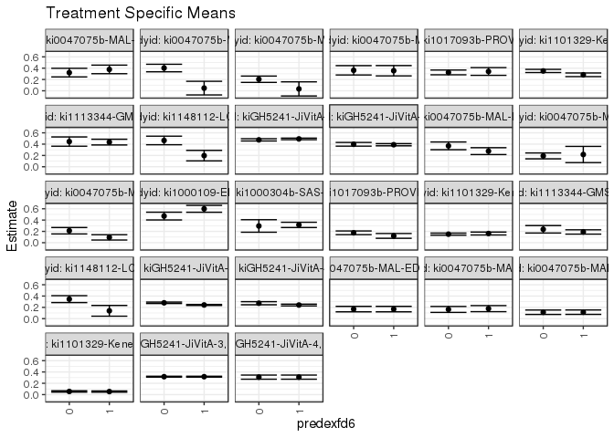

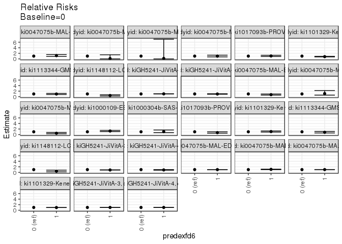

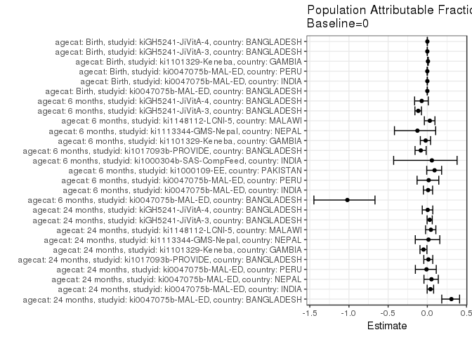

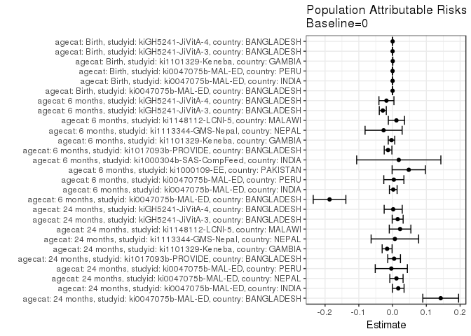

## Results Table

### Parameter: TSM

| agecat | studyid | country | intervention_level | baseline_level | estimate | ci_lower | ci_upper |
| --- | --- | --- | --- | --- | --- | --- | --- |
| Birth | ki0047075b-MAL-ED | BANGLADESH | 0 | NA | 0.1688278 | 0.1204163 | 0.2172393 |
| Birth | ki0047075b-MAL-ED | BANGLADESH | 1 | NA | 0.1688261 | 0.1204151 | 0.2172371 |
| Birth | ki0047075b-MAL-ED | INDIA | 0 | NA | 0.1631247 | 0.1104544 | 0.2157949 |
| Birth | ki0047075b-MAL-ED | INDIA | 1 | NA | 0.1771752 | 0.1235181 | 0.2308323 |
| Birth | ki0047075b-MAL-ED | PERU | 0 | NA | 0.1133237 | 0.0744057 | 0.1522417 |
| Birth | ki0047075b-MAL-ED | PERU | 1 | NA | 0.1143119 | 0.0754545 | 0.1531693 |
| Birth | ki1101329-Keneba | GAMBIA | 0 | NA | 0.0552203 | 0.0432875 | 0.0671531 |
| Birth | ki1101329-Keneba | GAMBIA | 1 | NA | 0.0533953 | 0.0418158 | 0.0649749 |
| Birth | kiGH5241-JiVitA-3 | BANGLADESH | 0 | NA | 0.3166338 | 0.3090249 | 0.3242426 |
| Birth | kiGH5241-JiVitA-3 | BANGLADESH | 1 | NA | 0.3166221 | 0.3090126 | 0.3242315 |
| Birth | kiGH5241-JiVitA-4 | BANGLADESH | 0 | NA | 0.3088609 | 0.2721065 | 0.3456153 |
| Birth | kiGH5241-JiVitA-4 | BANGLADESH | 1 | NA | 0.3089385 | 0.2721845 | 0.3456925 |
| 6 months | ki0047075b-MAL-ED | BANGLADESH | 0 | NA | 0.3696789 | 0.3013892 | 0.4379685 |
| 6 months | ki0047075b-MAL-ED | BANGLADESH | 1 | NA | 0.2762623 | 0.2157709 | 0.3367538 |
| 6 months | ki0047075b-MAL-ED | INDIA | 0 | NA | 0.1919642 | 0.1399508 | 0.2439776 |
| 6 months | ki0047075b-MAL-ED | INDIA | 1 | NA | 0.2162384 | 0.0726089 | 0.3598679 |
| 6 months | ki0047075b-MAL-ED | PERU | 0 | NA | 0.2118478 | 0.1550695 | 0.2686262 |
| 6 months | ki0047075b-MAL-ED | PERU | 1 | NA | 0.0944363 | 0.0477702 | 0.1411023 |
| 6 months | ki1000109-EE | PAKISTAN | 0 | NA | 0.4708749 | 0.4023086 | 0.5394413 |
| 6 months | ki1000109-EE | PAKISTAN | 1 | NA | 0.5989553 | 0.5383631 | 0.6595475 |
| 6 months | ki1000304b-SAS-CompFeed | INDIA | 0 | NA | 0.2957556 | 0.1850271 | 0.4064840 |
| 6 months | ki1000304b-SAS-CompFeed | INDIA | 1 | NA | 0.3149598 | 0.2685165 | 0.3614031 |
| 6 months | ki1017093b-PROVIDE | BANGLADESH | 0 | NA | 0.1746779 | 0.1417991 | 0.2075568 |
| 6 months | ki1017093b-PROVIDE | BANGLADESH | 1 | NA | 0.1203879 | 0.0780335 | 0.1627423 |
| 6 months | ki1101329-Keneba | GAMBIA | 0 | NA | 0.1510062 | 0.1324777 | 0.1695347 |
| 6 months | ki1101329-Keneba | GAMBIA | 1 | NA | 0.1623337 | 0.1369261 | 0.1877413 |
| 6 months | ki1113344-GMS-Nepal | NEPAL | 0 | NA | 0.2372053 | 0.1713451 | 0.3030655 |
| 6 months | ki1113344-GMS-Nepal | NEPAL | 1 | NA | 0.1899765 | 0.1519503 | 0.2280026 |
| 6 months | ki1148112-LCNI-5 | MALAWI | 0 | NA | 0.3452094 | 0.2839329 | 0.4064859 |
| 6 months | ki1148112-LCNI-5 | MALAWI | 1 | NA | 0.1385414 | 0.0435836 | 0.2334992 |
| 6 months | kiGH5241-JiVitA-3 | BANGLADESH | 0 | NA | 0.2798339 | 0.2670675 | 0.2926003 |
| 6 months | kiGH5241-JiVitA-3 | BANGLADESH | 1 | NA | 0.2421566 | 0.2335326 | 0.2507807 |
| 6 months | kiGH5241-JiVitA-4 | BANGLADESH | 0 | NA | 0.2727161 | 0.2453317 | 0.3001005 |
| 6 months | kiGH5241-JiVitA-4 | BANGLADESH | 1 | NA | 0.2408441 | 0.2251942 | 0.2564941 |
| 24 months | ki0047075b-MAL-ED | BANGLADESH | 0 | NA | 0.3215523 | 0.2452181 | 0.3978865 |
| 24 months | ki0047075b-MAL-ED | BANGLADESH | 1 | NA | 0.3781765 | 0.3021803 | 0.4541727 |
| 24 months | ki0047075b-MAL-ED | INDIA | 0 | NA | 0.4028214 | 0.3363631 | 0.4692798 |
| 24 months | ki0047075b-MAL-ED | INDIA | 1 | NA | 0.0477012 | -0.0726963 | 0.1680986 |
| 24 months | ki0047075b-MAL-ED | NEPAL | 0 | NA | 0.2044194 | 0.1482973 | 0.2605415 |
| 24 months | ki0047075b-MAL-ED | NEPAL | 1 | NA | 0.0333537 | -0.0919084 | 0.1586157 |
| 24 months | ki0047075b-MAL-ED | PERU | 0 | NA | 0.3623711 | 0.2796798 | 0.4450623 |
| 24 months | ki0047075b-MAL-ED | PERU | 1 | NA | 0.3550353 | 0.2640260 | 0.4460446 |
| 24 months | ki1017093b-PROVIDE | BANGLADESH | 0 | NA | 0.3247238 | 0.2826846 | 0.3667630 |
| 24 months | ki1017093b-PROVIDE | BANGLADESH | 1 | NA | 0.3417800 | 0.2735810 | 0.4099791 |
| 24 months | ki1101329-Keneba | GAMBIA | 0 | NA | 0.3506213 | 0.3228308 | 0.3784118 |
| 24 months | ki1101329-Keneba | GAMBIA | 1 | NA | 0.2830920 | 0.2505995 | 0.3155846 |
| 24 months | ki1113344-GMS-Nepal | NEPAL | 0 | NA | 0.4452523 | 0.3632698 | 0.5272348 |
| 24 months | ki1113344-GMS-Nepal | NEPAL | 1 | NA | 0.4357742 | 0.3851820 | 0.4863664 |
| 24 months | ki1148112-LCNI-5 | MALAWI | 0 | NA | 0.4645978 | 0.3887351 | 0.5404604 |
| 24 months | ki1148112-LCNI-5 | MALAWI | 1 | NA | 0.1966791 | 0.1037683 | 0.2895899 |
| 24 months | kiGH5241-JiVitA-3 | BANGLADESH | 0 | NA | 0.4757103 | 0.4557631 | 0.4956576 |
| 24 months | kiGH5241-JiVitA-3 | BANGLADESH | 1 | NA | 0.4923420 | 0.4784749 | 0.5062091 |
| 24 months | kiGH5241-JiVitA-4 | BANGLADESH | 0 | NA | 0.3972862 | 0.3644565 | 0.4301160 |
| 24 months | kiGH5241-JiVitA-4 | BANGLADESH | 1 | NA | 0.3894709 | 0.3701853 | 0.4087566 |

### Parameter: E(Y)

| agecat | studyid | country | intervention_level | baseline_level | estimate | ci_lower | ci_upper |
| --- | --- | --- | --- | --- | --- | --- | --- |
| Birth | ki0047075b-MAL-ED | BANGLADESH | NA | NA | 0.1688312 | 0.1204189 | 0.2172434 |
| Birth | ki0047075b-MAL-ED | INDIA | NA | NA | 0.1631579 | 0.1104782 | 0.2158376 |
| Birth | ki0047075b-MAL-ED | PERU | NA | NA | 0.1132812 | 0.0743812 | 0.1521813 |
| Birth | ki1101329-Keneba | GAMBIA | NA | NA | 0.0556745 | 0.0436637 | 0.0676854 |
| Birth | kiGH5241-JiVitA-3 | BANGLADESH | NA | NA | 0.3166335 | 0.3090239 | 0.3242430 |
| Birth | kiGH5241-JiVitA-4 | BANGLADESH | NA | NA | 0.3089961 | 0.2722361 | 0.3457561 |
| 6 months | ki0047075b-MAL-ED | BANGLADESH | NA | NA | 0.1829787 | 0.1334386 | 0.2325189 |
| 6 months | ki0047075b-MAL-ED | INDIA | NA | NA | 0.1939655 | 0.1429760 | 0.2449551 |
| 6 months | ki0047075b-MAL-ED | PERU | NA | NA | 0.2156134 | 0.1663773 | 0.2648495 |
| 6 months | ki1000109-EE | PAKISTAN | NA | NA | 0.5188172 | 0.4679751 | 0.5696593 |
| 6 months | ki1000304b-SAS-CompFeed | INDIA | NA | NA | 0.3140704 | 0.2712850 | 0.3568557 |
| 6 months | ki1017093b-PROVIDE | BANGLADESH | NA | NA | 0.1612350 | 0.1313580 | 0.1911120 |
| 6 months | ki1101329-Keneba | GAMBIA | NA | NA | 0.1477987 | 0.1318701 | 0.1637274 |
| 6 months | ki1113344-GMS-Nepal | NEPAL | NA | NA | 0.2106227 | 0.1763897 | 0.2448557 |
| 6 months | ki1148112-LCNI-5 | MALAWI | NA | NA | 0.3566176 | 0.2995882 | 0.4136471 |
| 6 months | kiGH5241-JiVitA-3 | BANGLADESH | NA | NA | 0.2508093 | 0.2426385 | 0.2589801 |
| 6 months | kiGH5241-JiVitA-4 | BANGLADESH | NA | NA | 0.2545198 | 0.2394884 | 0.2695513 |
| 24 months | ki0047075b-MAL-ED | BANGLADESH | NA | NA | 0.4641148 | 0.3963405 | 0.5318891 |
| 24 months | ki0047075b-MAL-ED | INDIA | NA | NA | 0.4196429 | 0.3548715 | 0.4844143 |
| 24 months | ki0047075b-MAL-ED | NEPAL | NA | NA | 0.2158590 | 0.1622206 | 0.2694975 |
| 24 months | ki0047075b-MAL-ED | PERU | NA | NA | 0.3585859 | 0.2916158 | 0.4255559 |
| 24 months | ki1017093b-PROVIDE | BANGLADESH | NA | NA | 0.3292894 | 0.2909105 | 0.3676684 |
| 24 months | ki1101329-Keneba | GAMBIA | NA | NA | 0.3344349 | 0.3106543 | 0.3582155 |
| 24 months | ki1113344-GMS-Nepal | NEPAL | NA | NA | 0.4520833 | 0.4075129 | 0.4966538 |
| 24 months | ki1148112-LCNI-5 | MALAWI | NA | NA | 0.4867725 | 0.4153250 | 0.5582200 |
| 24 months | kiGH5241-JiVitA-3 | BANGLADESH | NA | NA | 0.4907516 | 0.4775997 | 0.5039035 |
| 24 months | kiGH5241-JiVitA-4 | BANGLADESH | NA | NA | 0.3991375 | 0.3806098 | 0.4176653 |

### Parameter: RR

| agecat | studyid | country | intervention_level | baseline_level | estimate | ci_lower | ci_upper |
| --- | --- | --- | --- | --- | --- | --- | --- |
| Birth | ki0047075b-MAL-ED | BANGLADESH | 0 | 0 | 1.0000000 | 1.0000000 | 1.0000000 |
| Birth | ki0047075b-MAL-ED | BANGLADESH | 1 | 0 | 0.9999897 | 0.9999655 | 1.0000139 |
| Birth | ki0047075b-MAL-ED | INDIA | 0 | 0 | 1.0000000 | 1.0000000 | 1.0000000 |
| Birth | ki0047075b-MAL-ED | INDIA | 1 | 0 | 1.0861339 | 0.9996844 | 1.1800592 |
| Birth | ki0047075b-MAL-ED | PERU | 0 | 0 | 1.0000000 | 1.0000000 | 1.0000000 |
| Birth | ki0047075b-MAL-ED | PERU | 1 | 0 | 1.0087201 | 0.9936503 | 1.0240185 |
| Birth | ki1101329-Keneba | GAMBIA | 0 | 0 | 1.0000000 | 1.0000000 | 1.0000000 |
| Birth | ki1101329-Keneba | GAMBIA | 1 | 0 | 0.9669511 | 0.9538488 | 0.9802334 |
| Birth | kiGH5241-JiVitA-3 | BANGLADESH | 0 | 0 | 1.0000000 | 1.0000000 | 1.0000000 |
| Birth | kiGH5241-JiVitA-3 | BANGLADESH | 1 | 0 | 0.9999631 | 0.9999280 | 0.9999983 |
| Birth | kiGH5241-JiVitA-4 | BANGLADESH | 0 | 0 | 1.0000000 | 1.0000000 | 1.0000000 |
| Birth | kiGH5241-JiVitA-4 | BANGLADESH | 1 | 0 | 1.0002512 | 0.9996657 | 1.0008371 |
| 6 months | ki0047075b-MAL-ED | BANGLADESH | 0 | 0 | 1.0000000 | 1.0000000 | 1.0000000 |
| 6 months | ki0047075b-MAL-ED | BANGLADESH | 1 | 0 | 0.7473036 | 0.5711679 | 0.9777555 |
| 6 months | ki0047075b-MAL-ED | INDIA | 0 | 0 | 1.0000000 | 1.0000000 | 1.0000000 |
| 6 months | ki0047075b-MAL-ED | INDIA | 1 | 0 | 1.1264518 | 0.5724132 | 2.2167444 |
| 6 months | ki0047075b-MAL-ED | PERU | 0 | 0 | 1.0000000 | 1.0000000 | 1.0000000 |
| 6 months | ki0047075b-MAL-ED | PERU | 1 | 0 | 0.4457740 | 0.2600340 | 0.7641866 |
| 6 months | ki1000109-EE | PAKISTAN | 0 | 0 | 1.0000000 | 1.0000000 | 1.0000000 |
| 6 months | ki1000109-EE | PAKISTAN | 1 | 0 | 1.2720051 | 1.0782624 | 1.5005596 |
| 6 months | ki1000304b-SAS-CompFeed | INDIA | 0 | 0 | 1.0000000 | 1.0000000 | 1.0000000 |
| 6 months | ki1000304b-SAS-CompFeed | INDIA | 1 | 0 | 1.0649327 | 0.6879335 | 1.6485337 |
| 6 months | ki1017093b-PROVIDE | BANGLADESH | 0 | 0 | 1.0000000 | 1.0000000 | 1.0000000 |
| 6 months | ki1017093b-PROVIDE | BANGLADESH | 1 | 0 | 0.6891992 | 0.4833930 | 0.9826279 |
| 6 months | ki1101329-Keneba | GAMBIA | 0 | 0 | 1.0000000 | 1.0000000 | 1.0000000 |
| 6 months | ki1101329-Keneba | GAMBIA | 1 | 0 | 1.0750136 | 0.8885653 | 1.3005845 |
| 6 months | ki1113344-GMS-Nepal | NEPAL | 0 | 0 | 1.0000000 | 1.0000000 | 1.0000000 |
| 6 months | ki1113344-GMS-Nepal | NEPAL | 1 | 0 | 0.8008946 | 0.5695265 | 1.1262553 |
| 6 months | ki1148112-LCNI-5 | MALAWI | 0 | 0 | 1.0000000 | 1.0000000 | 1.0000000 |
| 6 months | ki1148112-LCNI-5 | MALAWI | 1 | 0 | 0.4013257 | 0.1988873 | 0.8098172 |
| 6 months | kiGH5241-JiVitA-3 | BANGLADESH | 0 | 0 | 1.0000000 | 1.0000000 | 1.0000000 |
| 6 months | kiGH5241-JiVitA-3 | BANGLADESH | 1 | 0 | 0.8653585 | 0.8234323 | 0.9094195 |
| 6 months | kiGH5241-JiVitA-4 | BANGLADESH | 0 | 0 | 1.0000000 | 1.0000000 | 1.0000000 |
| 6 months | kiGH5241-JiVitA-4 | BANGLADESH | 1 | 0 | 0.8831313 | 0.7911484 | 0.9858087 |
| 24 months | ki0047075b-MAL-ED | BANGLADESH | 0 | 0 | 1.0000000 | 1.0000000 | 1.0000000 |
| 24 months | ki0047075b-MAL-ED | BANGLADESH | 1 | 0 | 1.1760964 | 0.8905797 | 1.5531488 |
| 24 months | ki0047075b-MAL-ED | INDIA | 0 | 0 | 1.0000000 | 1.0000000 | 1.0000000 |
| 24 months | ki0047075b-MAL-ED | INDIA | 1 | 0 | 0.1184176 | 0.0094803 | 1.4791407 |
| 24 months | ki0047075b-MAL-ED | NEPAL | 0 | 0 | 1.0000000 | 1.0000000 | 1.0000000 |
| 24 months | ki0047075b-MAL-ED | NEPAL | 1 | 0 | 0.1631629 | 0.0037683 | 7.0648384 |
| 24 months | ki0047075b-MAL-ED | PERU | 0 | 0 | 1.0000000 | 1.0000000 | 1.0000000 |
| 24 months | ki0047075b-MAL-ED | PERU | 1 | 0 | 0.9797562 | 0.7170298 | 1.3387480 |
| 24 months | ki1017093b-PROVIDE | BANGLADESH | 0 | 0 | 1.0000000 | 1.0000000 | 1.0000000 |
| 24 months | ki1017093b-PROVIDE | BANGLADESH | 1 | 0 | 1.0525254 | 0.8449080 | 1.3111601 |
| 24 months | ki1101329-Keneba | GAMBIA | 0 | 0 | 1.0000000 | 1.0000000 | 1.0000000 |
| 24 months | ki1101329-Keneba | GAMBIA | 1 | 0 | 0.8074011 | 0.7069266 | 0.9221559 |
| 24 months | ki1113344-GMS-Nepal | NEPAL | 0 | 0 | 1.0000000 | 1.0000000 | 1.0000000 |
| 24 months | ki1113344-GMS-Nepal | NEPAL | 1 | 0 | 0.9787131 | 0.7889237 | 1.2141597 |
| 24 months | ki1148112-LCNI-5 | MALAWI | 0 | 0 | 1.0000000 | 1.0000000 | 1.0000000 |
| 24 months | ki1148112-LCNI-5 | MALAWI | 1 | 0 | 0.4233320 | 0.2574658 | 0.6960535 |
| 24 months | kiGH5241-JiVitA-3 | BANGLADESH | 0 | 0 | 1.0000000 | 1.0000000 | 1.0000000 |
| 24 months | kiGH5241-JiVitA-3 | BANGLADESH | 1 | 0 | 1.0349618 | 0.9905706 | 1.0813422 |
| 24 months | kiGH5241-JiVitA-4 | BANGLADESH | 0 | 0 | 1.0000000 | 1.0000000 | 1.0000000 |
| 24 months | kiGH5241-JiVitA-4 | BANGLADESH | 1 | 0 | 0.9803283 | 0.8982842 | 1.0698659 |

### Parameter: PAR

| agecat | studyid | country | intervention_level | baseline_level | estimate | ci_lower | ci_upper |
| --- | --- | --- | --- | --- | --- | --- | --- |
| Birth | ki0047075b-MAL-ED | BANGLADESH | 0 | NA | 0.0000034 | 0.0000013 | 0.0000054 |
| Birth | ki0047075b-MAL-ED | INDIA | 0 | NA | 0.0000332 | -0.0000168 | 0.0000832 |
| Birth | ki0047075b-MAL-ED | PERU | 0 | NA | -0.0000424 | -0.0003120 | 0.0002271 |
| Birth | ki1101329-Keneba | GAMBIA | 0 | NA | 0.0004542 | 0.0002051 | 0.0007033 |
| Birth | kiGH5241-JiVitA-3 | BANGLADESH | 0 | NA | -0.0000003 | -0.0000088 | 0.0000082 |
| Birth | kiGH5241-JiVitA-4 | BANGLADESH | 0 | NA | 0.0001352 | -0.0000039 | 0.0002743 |
| 6 months | ki0047075b-MAL-ED | BANGLADESH | 0 | NA | -0.1867001 | -0.2350611 | -0.1383391 |
| 6 months | ki0047075b-MAL-ED | INDIA | 0 | NA | 0.0020013 | -0.0094052 | 0.0134078 |
| 6 months | ki0047075b-MAL-ED | PERU | 0 | NA | 0.0037656 | -0.0260149 | 0.0335460 |
| 6 months | ki1000109-EE | PAKISTAN | 0 | NA | 0.0479423 | -0.0014090 | 0.0972936 |
| 6 months | ki1000304b-SAS-CompFeed | INDIA | 0 | NA | 0.0183148 | -0.1064003 | 0.1430298 |
| 6 months | ki1017093b-PROVIDE | BANGLADESH | 0 | NA | -0.0134429 | -0.0248087 | -0.0020772 |
| 6 months | ki1101329-Keneba | GAMBIA | 0 | NA | -0.0032075 | -0.0128463 | 0.0064314 |
| 6 months | ki1113344-GMS-Nepal | NEPAL | 0 | NA | -0.0265826 | -0.0814894 | 0.0283242 |
| 6 months | ki1148112-LCNI-5 | MALAWI | 0 | NA | 0.0114083 | -0.0126129 | 0.0354294 |
| 6 months | kiGH5241-JiVitA-3 | BANGLADESH | 0 | NA | -0.0290246 | -0.0393915 | -0.0186577 |
| 6 months | kiGH5241-JiVitA-4 | BANGLADESH | 0 | NA | -0.0181963 | -0.0404180 | 0.0040254 |
| 24 months | ki0047075b-MAL-ED | BANGLADESH | 0 | NA | 0.1425625 | 0.0895335 | 0.1955915 |
| 24 months | ki0047075b-MAL-ED | INDIA | 0 | NA | 0.0168214 | -0.0003936 | 0.0340365 |
| 24 months | ki0047075b-MAL-ED | NEPAL | 0 | NA | 0.0114396 | -0.0082072 | 0.0310864 |
| 24 months | ki0047075b-MAL-ED | PERU | 0 | NA | -0.0037852 | -0.0513973 | 0.0438269 |
| 24 months | ki1017093b-PROVIDE | BANGLADESH | 0 | NA | 0.0045656 | -0.0142393 | 0.0233705 |
| 24 months | ki1101329-Keneba | GAMBIA | 0 | NA | -0.0161864 | -0.0309147 | -0.0014581 |
| 24 months | ki1113344-GMS-Nepal | NEPAL | 0 | NA | 0.0068311 | -0.0636176 | 0.0772797 |
| 24 months | ki1148112-LCNI-5 | MALAWI | 0 | NA | 0.0221747 | -0.0098059 | 0.0541553 |
| 24 months | kiGH5241-JiVitA-3 | BANGLADESH | 0 | NA | 0.0150412 | -0.0011765 | 0.0312589 |
| 24 months | kiGH5241-JiVitA-4 | BANGLADESH | 0 | NA | 0.0018513 | -0.0249216 | 0.0286242 |

### Parameter: PAF

| agecat | studyid | country | intervention_level | baseline_level | estimate | ci_lower | ci_upper |
| --- | --- | --- | --- | --- | --- | --- | --- |
| Birth | ki0047075b-MAL-ED | BANGLADESH | 0 | NA | 0.0000199 | 0.0000085 | 0.0000312 |
| Birth | ki0047075b-MAL-ED | INDIA | 0 | NA | 0.0002037 | -0.0000974 | 0.0005047 |
| Birth | ki0047075b-MAL-ED | PERU | 0 | NA | -0.0003746 | -0.0027522 | 0.0019974 |
| Birth | ki1101329-Keneba | GAMBIA | 0 | NA | 0.0081584 | 0.0039026 | 0.0123959 |
| Birth | kiGH5241-JiVitA-3 | BANGLADESH | 0 | NA | -0.0000009 | -0.0000277 | 0.0000260 |
| Birth | kiGH5241-JiVitA-4 | BANGLADESH | 0 | NA | 0.0004375 | -0.0000136 | 0.0008884 |
| 6 months | ki0047075b-MAL-ED | BANGLADESH | 0 | NA | -1.0203379 | -1.4474281 | -0.6677774 |
| 6 months | ki0047075b-MAL-ED | INDIA | 0 | NA | 0.0103179 | -0.0502765 | 0.0674164 |
| 6 months | ki0047075b-MAL-ED | PERU | 0 | NA | 0.0174645 | -0.1307644 | 0.1462624 |
| 6 months | ki1000109-EE | PAKISTAN | 0 | NA | 0.0924069 | -0.0077185 | 0.1825840 |
| 6 months | ki1000304b-SAS-CompFeed | INDIA | 0 | NA | 0.0583142 | -0.4299144 | 0.3798425 |
| 6 months | ki1017093b-PROVIDE | BANGLADESH | 0 | NA | -0.0833749 | -0.1565792 | -0.0148040 |
| 6 months | ki1101329-Keneba | GAMBIA | 0 | NA | -0.0217016 | -0.0891159 | 0.0415400 |
| 6 months | ki1113344-GMS-Nepal | NEPAL | 0 | NA | -0.1262096 | -0.4195170 | 0.1064932 |
| 6 months | ki1148112-LCNI-5 | MALAWI | 0 | NA | 0.0319902 | -0.0378259 | 0.0971097 |
| 6 months | kiGH5241-JiVitA-3 | BANGLADESH | 0 | NA | -0.1157239 | -0.1582692 | -0.0747414 |
| 6 months | kiGH5241-JiVitA-4 | BANGLADESH | 0 | NA | -0.0714925 | -0.1623605 | 0.0122718 |
| 24 months | ki0047075b-MAL-ED | BANGLADESH | 0 | NA | 0.3071708 | 0.1841889 | 0.4116134 |
| 24 months | ki0047075b-MAL-ED | INDIA | 0 | NA | 0.0400851 | -0.0020963 | 0.0804909 |
| 24 months | ki0047075b-MAL-ED | NEPAL | 0 | NA | 0.0529958 | -0.0428069 | 0.1399971 |
| 24 months | ki0047075b-MAL-ED | PERU | 0 | NA | -0.0105559 | -0.1524375 | 0.1138580 |
| 24 months | ki1017093b-PROVIDE | BANGLADESH | 0 | NA | 0.0138651 | -0.0448823 | 0.0693095 |
| 24 months | ki1101329-Keneba | GAMBIA | 0 | NA | -0.0483993 | -0.0935686 | -0.0050957 |
| 24 months | ki1113344-GMS-Nepal | NEPAL | 0 | NA | 0.0151102 | -0.1536704 | 0.1591984 |
| 24 months | ki1148112-LCNI-5 | MALAWI | 0 | NA | 0.0455545 | -0.0222393 | 0.1088523 |
| 24 months | kiGH5241-JiVitA-3 | BANGLADESH | 0 | NA | 0.0306494 | -0.0029016 | 0.0630780 |
| 24 months | kiGH5241-JiVitA-4 | BANGLADESH | 0 | NA | 0.0046382 | -0.0647550 | 0.0695088 |